# AI Washing or Credible Disclosure? · Thesis defense

MBA in International Business · XXXVI edition · Final report

AI Washing or Credible Disclosure?

Patterns and Clusters in Corporate AI Disclosures

Author

Germán Oviedo

Discussant

Prof. Francesco Venier

## Once nearly every firm disclosed AI, the managerial problem shifted from presence to credibility

The problem

S&P 500 firms mentioning AI in SEC filings

34%→93%

2021 → 2025. Over the same years AI frames per 1,000 words grew **7.3×**.

When 93.5% of firms mention AI, **a mention alone says almost nothing.** What matters is *how* firms talk about it and what evidence backs it.

[figure not shown]

S&P 500, 499 firms fixed at 1 Jan 2021 · SEC filings 2021–2025, 2026 year to date · Thesis Fig. 3

## Four research questions structure the inquiry from disclosure patterns to economic relevance

Research design

Main research question

To what extent do public firms exhibit **strategic heterogeneity** in their corporate AI disclosures, and does distinguishing disclosure volume, communication posture and grounded operational substance carry incremental economic information?

RQ1 · Evolution

#### How did AI disclosure spread, and did the evidence keep up?

Institutional isomorphism

**Expected:** AI talk spreads fast; concrete activities grow more slowly.

RQ2 · Heterogeneity

#### Do firms talk about AI in distinct, stable ways?

Signalling · organizational configurations

**Expected:** stable styles that predict reported activity beyond volume.

RQ3 · Decoupling & venue

#### Does talk run ahead of evidence, and do calls differ from filings?

Decoupling · channel liability

**Expected:** unbacked promotion sits in calls; SEC scrutiny narrows the gap.

RQ4 · Market relevance

#### Do markets price these differences?

Costly signalling

**Expected:** accumulated gaps, not one quarter’s talk, show up in risk.

## An analytical methodology turns 9.7M paragraphs into six measures to explore the four questions

Methodology

[figure not shown]

S&P 500, 499 firms · 10-K, 10-Q, 8-K, DEF 14A and earnings calls, 2021–2026 year to date · Thesis Fig. 1  
communication disclosed activity & evidence decoupling · Code, prompts, datasets and models are public and version-pinned.

## AI talk grew 7.3× and turned toward risk and governance

RQ1 / Narrative evolution

[figure not shown]

The typical firm now talks about AI mostly as a **risk**: the share of its AI frames that name one rose from **23% to 58%**, while realized claims fell from 74% to 55% and customer-facing ones from 35% to 11%. The turn starts in 2023, ahead of the SEC warning (A12).

Filings 2021–2025, 2026 year to date · Left: Thesis Fig. 3, Panel B  
Right: the seven archetypal-analysis inputs by year. Per firm, share of its 10-K, 8-K and DEF 14A AI frames carrying each dimension (≥ 5 frames, shrunk), averaged across firms.

## Firms report many more AI activities, each backed by less evidence

RQ1 / Evolution of evidence

[figure not shown]

More activities

Firms report **5.1×** more AI activities in 2025 than in 2021.

Where evidence is missing

Most activities name a business function and are deployed. Few give a number for the result (**13%**) or name an outside vendor (**3%**).

Less evidence each

G = share of the 5 items an activity names, per firm. It fell **0.44 → 0.37**, also in firms already there in 2021.

Left: 2021–2025, 2026 YTD (hatched = projected), filings and calls · Middle: each attribute counted on its own, all 46,855 activities, pooled 2021–2026 YTD (Thesis Fig. 13, right) · Right: firm *G* from filings (Thesis Fig. 14)

## Almost every firm talks about AI, but in three distinct postures that also differ in what firms report doing

RQ2 / Heterogeneity

[figure not shown]

78 firms

#### Vocal Substantives

Customer-facing, specific and promotional. Microsoft, NVIDIA, Alphabet, Amazon.

**2.02×** the activities of Defensive firms at equal volume

91 firms

#### Governance-Led

Board oversight and responsible use; realized claims. Citigroup, Apple, BlackRock.

**1.52×** the activities of Defensive firms at equal volume

282 firms

#### Defensive

AI as a risk in Item 1A; few realized claims. Goldman Sachs, J&J.

Volume and activities are not used to find the postures

451 firms · 10-K, 8-K, DEF 14A · pooled 2021–2026 YTD · Thesis Fig. 5

## New disclosers mostly enter as Defensive, and industry shapes which posture a firm takes

RQ2 / Postures over time and by sector

Share of the index in each posture

[figure not shown]

By sector: share vs. the index average (1.0× = average)

[figure not shown]

Left: all index firms each year, 2021–2025, 2026 year to date · Right: pooled 2021–2026 year to date · Thesis Figs. 8 (Panel A) and 7

## Some firms’ talk runs ahead of their evidence, and the gap persists year to year

RQ3 / Decoupling

[figure not shown]

S = activities weighted by their evidence G

W = rank of talk D − rank of evidence S, within each year

W > 0: talk ahead of evidence · W < 0: quiet substance

ρ = 0.60

a firm’s *W* this year predicts next year’s: a stable trait, not noise

High *W*: “The Company **may use** artificial intelligence…”  
Low *W*: “Deploy AI… through our global **Aon Business Services platform**.”

One point per disclosing firm, ranked within 2025 · Thesis Fig. 20  
*W* ranks firms against each other. A high *W* is a reason to check, not proof of overstatement.

## Disclosure signals show selective associations with risk, returns and growth

RQ4 / Market relevance

[figure not shown]

Over time, not one call  
Past decoupling and cumulative volume go with a more positive beta shift; single-call decoupling shows no robust association in this sample.

Governance vs. Defensive  
Lower beta shift, higher drift over the next quarter, slower revenue growth.

No survivors  
Announcement return, crash risk, gross margin, ROIC–WACC.

survives BH-FDR 5% (6 of 48) nominal p < 0.05 only · calls 2021–2026; sample varies by outcome (beta shift: 9,350 calls, 484 firms) · sector & year FE · **association, not cause** · Thesis Table 46

## A four-step framework to prioritize and verify AI claims

Managerial application

Due diligence  
93% of firms mention AI in their filings; nobody can check every claim. This says which to check first, before you invest, lend or sign.

Credibility  
Overstated AI is a misstatement for the SEC, and inflated claims cost trust with investors long before a letter arrives.

Downstream  
Disclosure gaps, intensity and posture show selective associations with risk, returns and growth. Use it at scale or on one company.

1

#### Define

Start with the company: what role does AI play in its business, **core or peripheral**?

Then fix the channels to read and the decision on the table.

2

#### Diagnose

Three questions, in order:

- **Posture:** how does it talk about AI? (sets the peers)
- **Evidence:** is there substance behind the talk?
- **Venue:** are scope and evidence consistent across call and 10-K?

NLP at scale, or by hand.

3

#### Prioritize & verify

Start with the claims that **matter most to the business**. Look for:

- deployed or just a pilot?
- named product? metric?
- in-house or vendor?
- same scope in call and 10-K?

Claims missing these go first.

NLP at scale, or by hand.

4

#### Act & monitor

Log each claim in a **claim register** (owner, review date). Then:

- **Evidence not communicated:** decide what to disclose.
- **Nothing behind it:** why talk about AI at all? Narrow it, back to step 1.
- **Backed:** keep it, review next cycle.

Beyond large listed firms

**Private firms:** promises vs. board reports and contracts.

**Startups:** demo, pilot or paying customers?

**Everywhere:** is there proof? (S&P 500 numbers don’t carry over)

## Applied at scale to the S&P 500 in 2026: the screen says where to look, the routine says what to do next

Managerial application / The routine in practice

2026 screen · 465 index firms

Investigate · 56

much talk, little evidence

Validate · 166

much talk, much evidence

Deprioritize · 187

little talk, little evidence

Explore · 56

little talk, much evidence

One firm per quadrant, through the four steps · 2026

|  | 1 · Define | 2 · Diagnose | 3 · Prioritize & verify | 4 · Act & monitor |
| --- | --- | --- | --- | --- |
| **Microsoft** Validate | AI is **core**: products and cloud. | Vocal. Talk 100th pct, evidence 97th pct, *W* +0.03. | 277 activities, 132 with a number. Do customers use them, and do they bring in money? | **Documentary alignment is strong; verify adoption and economic contribution.** |
| **Newell Brands** Investigate | AI is **peripheral**: housewares and pens. | Defensive. Talk 71st pct, evidence 39th pct, *W* +0.31. | 18 AI passages in the 10-K, half “we **may use** AI” risks. 11 of 13 activities name nothing. | **Little operational backing is disclosed; distinguish risk warnings from capability claims.** |
| **Wells Fargo** Explore | AI is **supporting**: operations and service. | Governance-Led. Talk 30th pct, evidence 84th pct, *W* −0.54. | AI tools in check processing and customer service, but few metrics. | **Documented activity exceeds narrative intensity; verify results and decide what to disclose.** |
| **ExxonMobil** Deprioritize | AI is **peripheral**: oil and gas. | Defensive. Talk 7th pct, evidence 12th pct, *W* −0.05. | Only 3 AI passages in the 10-K, but a call cites ~$750M saved with advanced modeling. | **A big number on a call:** ask for the backing. Materiality beats the queue. |

Screening applied to the sample; managerial responses are illustrative and their effectiveness remains untested.  
2026 reporting season (year to date) · screen: median splits of *D* and *S* among 444 disclosers (Thesis Table 16) · percentiles within 2026 · more cases in A15, quadrant examples in A16.

## AI talk spread faster than its evidence, firms exhibit distinct postures, and selected disclosure signals carry economic information

Findings & synthesis

RQ1 · Evolution

0.44 → 0.37

**Evidence thinned as talk spread.** AI reached 93% of firms and 7.3× more text, while average evidence per activity (*G*) fell.

RQ2 · Heterogeneity

3 postures

**Style predicts substance.** At equal volume, Vocal firms report 2.02× the activities of Defensive ones; new disclosers enter as Defensive.

RQ3 · Decoupling

ρ = 0.60

**The talk–evidence gap is a firm trait.** A firm’s *W* this year predicts next year’s: a stable characteristic across reporting cycles.

RQ4 · Market relevance

6 of 48

**Accumulated, not one call.** Past gaps and cumulative volume go with a higher beta shift; Governance-Led with lower beta shift and more drift.

What the thesis adds

- **A way to measure** talk and evidence separately, at scale
- **A due-diligence framework** from the findings: which AI claims to check first, at scale or for one firm
- **Open and reproducible:** public code, data and models, adaptable to new questions

What comes next

- Does it hold in longer periods and wider samples?
- Does it work for private companies?
- Does the framework help analysts decide better?
- What do new analyses and crosstabs reveal across sectors and technologies?

Questions & answers

Annex

## Six measures keep talk and evidence apart

A1 / Constructs

↩︎ Annex index

|  | Construct | Definition | Reads as |
| --- | --- | --- | --- |
| D | AI disclosure intensity | AI frames per 1,000 words | How much the firm talks about AI |
| P | Communication posture | Shares of claims that are promotional, hedged, risk, governance, realized, customer-facing, specific | *How* it talks |
| A | Disclosed AI activity | Count of action triples (verb · AI object · business function) | Breadth of reported execution |
| G | Activity grounding | ⅕ Σ<sub>k</sub> (activities naming *k* ÷ *A*) over 5 attributes *k*: function, deployed stage, named product, metric, provider. ∈ [0, 1]; shrunk when a firm has few activities | How verifiable each activity is |
| S | Disclosed substance | log(1 + *A*) × *G* | Grounded activity volume |
| W | Decoupling | rank(*D*) − rank(*S*) ∈ [−1, 1], ranks within year among disclosers | Talk ahead of substance (+) or quiet substance (−) |

Firm-year values are the median document rate; thin evidence is shrunk toward the sector-year prior (empirical Bayes).

## Each research question: its sources, measures and analysis

A2 / Architecture

↩︎ Annex index

|  | Sources | Components and how each is computed | Analysis that answers the RQ | Finding |
| --- | --- | --- | --- | --- |
| **RQ1** Evolution Institutional isomorphism | 10-K, 10-Q, 8-K, DEF 14A + earnings calls for the activity count | *D* = AI frames per 1,000 words *A* = count of action triples (verb · AI object · function) *G* = ⅕ Σ<sub>k</sub> (activities naming *k* ÷ *A*), 5 attributes | Yearly panel of *D*, *A*, *G*; fixed 2021 cohort to rule out composition | 34% → 93% of firms; activities 5.1×; *G* 0.44 → 0.37 |
| **RQ2** Heterogeneity Signalling; configurations | 10-K, 8-K, DEF 14A for *P* filings + calls for *A*; SIC codes | *P* = 7 frame shares (promotional, hedging, risk, governance, realized, customer-facing, specific) | Archetypal analysis on *P*, *k* = 3 by bootstrap Jaccard; negative binomial of *A* on posture + log(1 + frames) | Three postures; 2.02× / 1.52× activity at equal volume |
| **RQ3** Decoupling & venue Decoupling; channel liability | Filings for *W* calls vs. 10-K + 10-Q of the same fiscal year; SEC comment letters | *S* = log(1 + *A*) × *G* *W* = rank(*D*) − rank(*S*), within year | Persistence of *W*; venue gap *Y* = α<sub>i,t</sub> + β·1[call], firm × year FE | *W* persists (ρ 0.60); calls carry more evidence, filings more caveats |
| **RQ4** Market relevance Costly signalling | 9,350 earnings calls + prior filings FactSet prices, returns, market cap, S&P 500 TR, quarterly fundamentals | *W*<sub>call</sub> = *W* of the call; *W*<sub>exp</sub> = mean of past call *W*; cumulative *D*; posture weights | Regression: predetermined regressors, lagged outcome, sector & year FE; BH-FDR over 48 tests | 6 of 48 survive: beta shift, drift, revenue |

Validation: AI patents from Google Patents, OECD taxonomy (A4). SEC warning and DeepSeek: interrupted time series on filings and calls (A12, A13).

## From 9.7M paragraphs to 46,855 activities, each traceable to its sentence

A3 / Pipeline detail

↩︎ Annex index

| Stage | Retained | Operation |
| --- | --- | --- |
| Raw corpus | 9,714,405 | Paragraph segmentation of 59,820 documents |
| Scorable | 8,891,944 | Prose only; tables, exhibits, graphics dropped |
| Unique | 5,122,492 | BLAKE2b content hash; each text scored once |
| AI candidates | 38,440 | GBDT, 39 features (bge-m3 anchor similarity, stems, entities, section), τ = 0.17 |
| Texts with ≥1 claim | 31,550 | Zero-shot LLM → 70,169 frames, 7 dimensions + sentence anchor |
| Texts with firm action | 28,229 | Second pass → 46,855 activities: triple, stage, provenance, evidence |

Why this design

- Recall-first screen: a missed AI paragraph is lost for good; a false positive only costs one LLM call.
- Deduplication stops boilerplate from being counted, or paid for, twice.
- Every label keeps its sentence anchor, so any number traces back to text.
- Extraction model chosen on a 7-model benchmark: no field contradictions, ≈3 s per paragraph.

## Automated checks support the measures; the human audit is still pending

A4 / Validation

↩︎ Annex index

Screen transfer · unseen forms

0.97 recall

precision 0.67 · DEF 14A + 8-K, 1,500 texts. Calls: recall 0.98, precision 0.59 (0.85 on strong positives).

External benchmark · AI patents

+0.43 p < 0.001

log patents on log disclosed activity, 343 firms, size + SIC fixed effects; grounded activity +0.41.

Aggregation robustness

ρ > 0.96

posture scores and archetypes when borderline categories are collapsed or reweighted.

Limitation stated plainly

Accuracy labels come from a **second, independent LLM**, not from humans. A human validator is built (one factual question at a time, evidence highlighted) and stratified samples are drawn (300 prefilter paragraphs; 120 paragraphs with 267 activities), but they are **not yet reviewed**. No human-audited error rate is claimed.

Screen: held-out texts from forms not used in training · Patents: 2021–2023 filings, 343 firms · Thesis Table 37

## Three postures is the most stable choice

A5 / Choosing k

↩︎ Annex index

[figure not shown]

**k = 2** is stable but merges governance into promotion, so board oversight and a risk warning look the same.

**k = 4** fails: the fourth archetype falls to Jaccard 0.37. There is no stable promotional-but-vague style.

**Out of sample:** a model frozen on 2021–2025 recovers the 2026 partition (ARI 0.63); K-means reproduces the same three groups.

50 bootstrap replicates per k · Thesis Fig. 9

## Postures come from how firms talk, not from volume or activities

A6 / What the fit uses

↩︎ Annex index

Archetype vertices, fitted on seven posture shares only

[figure not shown]

**PCA of the seven inputs.** PC1 (46%) sets promotional, specific, customer-facing and realized against risk: the Vocal–Defensive axis. PC2 (19%) is governance (+0.71), unrelated to risk (r = −0.02). Three components reach 78%, so posture is not one scale.

In the fit

Seven frame-level P shares: promotional, hedging, risk, governance, realized, customer-facing, specificity.

Out of the fit

D (volume) and A (activities), both measured separately and used only afterwards as coherence checks.

Raw activity gap Vocal vs. Defensive: **7.9×**. Holding volume fixed: **2.02×** (CI 1.67–2.44). Volume matters; posture still adds.

Pooled 2021–2026 year to date · z-scores against the pooled mean · Thesis Fig. 6

## W ranks talk against evidence; it does not detect lying

A7 / What W measures

↩︎ Annex index

*W* = rank(*D*) − rank(*S*), *S* = log(1 + *A*) × *G*

- **Relative, within year:** percentile ranks among disclosers, so the yearly mean is ~0 by design. It sorts firms; the market-wide decline shows in *G* instead.
- **Ranks, not z-scores:** *D* has a far heavier tail, so z-scores would push Microsoft or NVIDIA into the “washing” tail.
- **Stable trait:** year-over-year ρ = 0.60; split-half ρ = 0.63; regression-residual version ρ = 0.81.
- **Not size or risk:** no association with market cap, beta or R&D intensity.

Explanations for a high *W* include competition, editorial convention and disorganisation, as well as overstatement. Telling them apart needs internal evidence.

## Same firm, same year: calls promote more and also provide more documentary evidence than filings

A8 / Calls vs. filings

↩︎ Annex index

Earnings call minus statutory filing, same firm and fiscal year (pp, 95% CI)

[figure not shown]

Per 1,000 words, calls carry

16.8×

more promotional statements

18.7×

more quantified outcome claims

Calls carry the proof, filings the caveats. **The warning sign is a call claim the 10-K doesn’t back.**

790 firm-years (285 firms, ≥ 3 activities in each channel), pooled 2021–2026 year to date, firm × fiscal-year fixed effects, 95% CI · Thesis Fig. 22 · ratios per 1,000 words: Thesis Fig. 24

## Calls vs. filings: same firm, same year

A9 / Venue design

↩︎ Annex index

*Y*<sub>i,t,venue</sub> = α<sub>i,t</sub> + β · 1[venue = call] + ε<sub>i,t,venue</sub>

Cells

790

firm-years, 285 firms, ≥ 3 activities in each channel

Each cell

All calls of the fiscal year pooled vs. the 10-K and 10-Qs of that year; shares of activities or rates per 1,000 words.

Inference

α<sub>i,t</sub> absorbs everything fixed about the firm that year; SE clustered by firm.

**By year:** the quantified-outcome premium in calls exists from 2021 and stays flat; the named-product gap opens with GenAI; governance caveats keep moving into filings.

**Limit:** the comparison is at venue level. It does not track whether a specific call claim reappears, softened, in the next filing.

## The market tests measure association, not cause

A10 / Identification

↩︎ Annex index

*Y*<sub>i,t</sub> = α + β · Disclosure<sub>i,t⁻</sub> + γ · *Y*<sub>i,t⁻</sub> + δ · Controls<sub>i,t⁻</sub> + Sector<sub>i</sub> + Year<sub>t</sub> + ε<sub>i,t</sub>

| Regressor | Measured |
| --- | --- |
| *W*<sub>call</sub> | this call’s own transcript |
| *W*<sub>exp</sub> | expanding mean of past call *W* |
| *D* | cumulative filing intensity to prior quarter |
| has · *w*<sub>voc</sub> · *w*<sub>gov</sub> | trailing posture mix, Defensive = reference |
| Controls | log mkt cap, 60-day return, ROA (+ KLZ for crash risk) |

| Outcome | Window |
| --- | --- |
| Beta shift (Brenner) | days [−63,−21) vs [+21,+63) |
| CAR [−1,+1] · drift [+2,+63] | market-model residuals |
| NCSKEW · DUVOL | 26 weeks after |
| Margin · ROIC−WACC · revenue | next 4 vs. prior 4 quarters |

Predetermined regressors, lagged outcome, firm-clustered SE. Cross-sectional association: changing the wording would not mechanically change beta.

## Evidence thins inside the same firms too, not only through new entrants

A11 / Robustness

↩︎ Annex index

[figure not shown]

- **Within firms:** the fixed 2021 cohort dilutes its own claims, 0.44 → 0.39.
- **Entry:** from 2023, new disclosers enter at or below incumbents.
- **Rollup:** activity- and firm-weighted versions agree, and calls are more grounded than filings under both.
- **Ladder:** pooling filings and calls, 2021–2026, only 9.7% of activities name a function, are deployed *and* give a metric.

Firm-years with a *W* score, 2021–2026 year to date · fixed cohort = firms already scored in 2021

## Risk and governance talk rose before the SEC warning, not at it

A12 / Regulatory scrutiny

↩︎ Annex index

[figure not shown]

**Sweep:** refitting the break month from 2023 to 2025, the best fit is early 2023 (governance Jan, risk Mar). The step at December 2023 is indistinguishable from zero.

**Direct scrutiny is rare:** 8 AI-term comment-letter threads in the universe, 1 on operational claims (Welltower, 2025). Its next 10-K cut claim density and moved *W* from +0.14 to −0.13.

Monthly AI frames per 1,000 words, all documents, from Jan 2021 (68 months) · break month tested from Jan 2023 to Jun 2025

## A two-month spike in open-source talk around DeepSeek, with no detectable lasting shift

A13 / Technology shock

↩︎ Annex index

[figure not shown]

Earnings calls, Jan 2021–Aug 2026 · Thesis Fig. 19  
Interrupted time series, 68 months of calls, season and composition controls, Jan–Feb 2025 as pulse terms. January ≈ 10× the prior monthly mean; lasting level change p = 0.78. Analysts named the model (AT&T, Corning calls).

## The screen ranks what to check first; it does not score credibility

A14 / Framework

↩︎ Annex index

2026 screen · 465 index firms

Investigate

56

High *D*, low *S* · ask for proof; compare call and 10-K

Validate

166

High *D*, high *S* · check the proof still holds

Deprioritize

187

Low *D*, low *S* · incl. 21 non-disclosers

Explore

56

Low *D*, high *S* · find what they do but don’t say

Median splits among 444 disclosers; persistent *W* orders the queue inside a cell. Reconcile screen: 32 of 447 dual-channel issuers with promotional gap z > 1.5.

| Verification finds | Issuer | Investor |
| --- | --- | --- |
| Real work, poor records | Write it down, name an owner | Ask for proof before believing it |
| Proof exists, never said | Decide what to tell | Look into it; don’t assume a bargain |
| Claim bigger than reality | Say less | Wait for milestones |
| Works, but no money yet | Check cost and usage | Don’t pay for it yet |
| Important and proven | Decide on the business case | Count it in the valuation |

Empirically estimated: *D, P, A, G, S, W*. Proposed: the decision process around them. Materiality comes from outside and can reverse the queue.

## The same routine leads to different next steps, firm by firm

A15 / Worked cases

↩︎ Annex index

| Firm | Posture | Talk *D* | Evidence *S* | *W* | What to check next |
| --- | --- | --- | --- | --- | --- |
| **Microsoft** 2024 | Vocal | 100th pct | 99th pct | +0.01 | Its talk matches its proof. Check that people use the products and that they make money. |
| **JPMorgan** 2024 | Governance-Led | 29th pct | 64th pct | −0.34 | Does more than it says. Ask: is it hiding it on purpose, or just not telling? |
| **Goldman Sachs** 2024 | Defensive | 59th pct | 68th pct | −0.08 | Talks about AI mostly as a risk. Ask: is any of it actually running? |
| **Apple** 2024 | Governance-Led | 94th pct | 79th pct | +0.15 | Talks a lot about AI privacy and rules, shows little use. Ask: where is AI actually used? |
| **Welltower** 2025 | Defensive | 59th pct | 44th pct | +0.14 | Said more on the call than in the 10-K, and the SEC asked. Make the two say the same. |

More examples, 2025 · three situations

| Situation | Firms · talk pct / evidence pct / *W* | What to check next |
| --- | --- | --- |
| **Talk ahead** | Newell Brands 76 / 11 / +0.65 · Gartner 90 / 31 / +0.59 · IFF 82 / 24 / +0.58 | Ask for the proof: which product, which result? |
| **Aligned** | NVIDIA 100 / 100 / 0.00 · Amazon 99 / 99 / 0.00 · Centene 77 / 77 / 0.00 | Proof matches the talk. Keep checking it each year. |
| **Evidence ahead** | CVS 54 / 88 / −0.34 · Aon 55 / 87 / −0.33 · JPMorgan 52 / 83 / −0.31 | Ask what they do but don’t say, and why. |

Top: the five thesis cases (2024; Welltower 2025). Bottom: 2025 percentiles among disclosers; talk-ahead, evidence-ahead, Amazon and Centene cases from Thesis Fig. 21.  
Percentiles within year across the index. A negative *W* places a firm against peers; it does not prove hidden capability. A positive one is a reason to check, not proof of overstatement.

## Each screen quadrant, with real firms from 2026

A16 / Quadrant examples

↩︎ Annex index

Investigate · 56 firms · lots of talk, little evidence

**First in line:** KLA, Fox, Newell Brands

**Familiar names:** Procter & Gamble, Verizon

Ask for proof, and check the call says the same as the 10-K.

Validate · 166 firms · lots of talk, lots of evidence

**First in line:** Gartner, Lam Research, Cintas

**Familiar names:** Microsoft, NVIDIA, Alphabet, Amazon, Apple, JPMorgan

Proof is there. Check it still holds next year.

Deprioritize · 187 firms · little talk, little evidence

**First in line:** Skyworks, Crown Castle, International Paper

**Familiar names:** ExxonMobil, Johnson & Johnson, Netflix, McDonald’s

Little to check, unless AI matters a lot to your decision.

Explore · 56 firms · little talk, lots of evidence

**First in line:** American Electric Power, Wells Fargo, Regions Financial

**Familiar names:** Visa, Coca-Cola, Citigroup, AT&T

They do more than they say. Find out what.

Quadrants split at the 2026 median of *D* and *S* among disclosers; Deprioritize includes 21 non-disclosers. “First in line” = highest persistent *W* (Explore: most negative), the thesis’s order for the queue.

Thesis figures not shown above

Supplementary

## Industrial distribution of the S&P 500 study universe (fixed at 2021-01-01, N=499) across three classification tiers

S1 / Thesis Figure 2

↩︎ Supplementary index

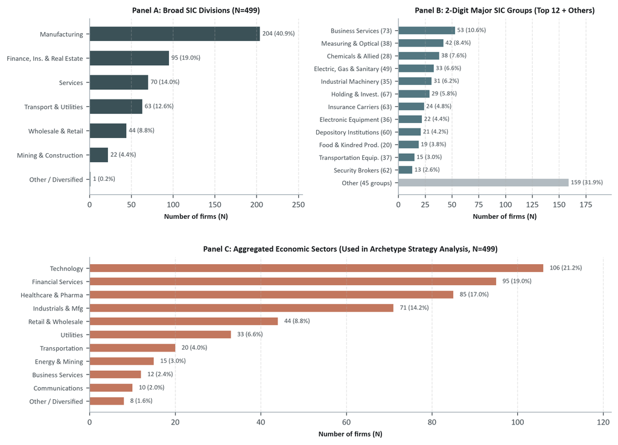

Panel A: broad SIC divisions. Panel B: two-digit SIC major groups (top 12 plus remaining). Panel C: 11 aggregated economic sectors.

## Distribution of Seven AI Disclosure Posture Dimensions and Disclosure Intensity Across the S&P 500, pooled 2021–2026 YTD

S2 / Thesis Figure 4

↩︎ Supplementary index

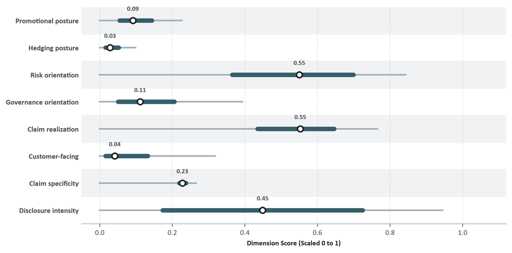

White circles denote medians; petrol bars interquartile ranges; grey whiskers the 5th–95th percentile. All measures are scaled from 0 to 1.

## AI disclosure diffuses primarily through defensive reporting: annual composition and firm-level transitions, 2021–2026 YTD

S3 / Thesis Figure 8

↩︎ Supplementary index

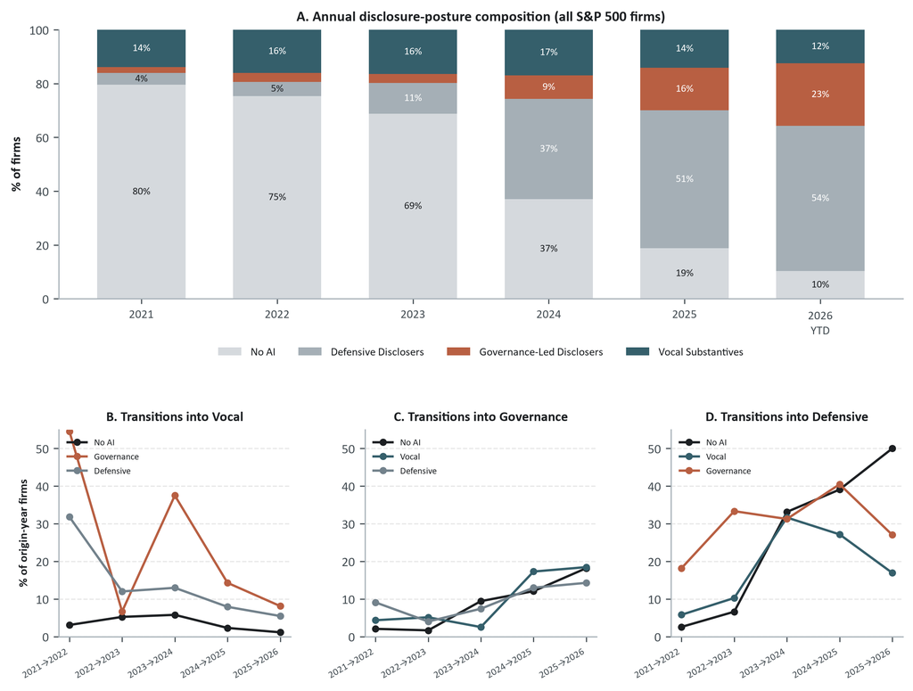

## Sectoral business purpose and operational action of disclosed AI activity, pooled 2021–2026 YTD

S4 / Thesis Figure 10

↩︎ Supplementary index

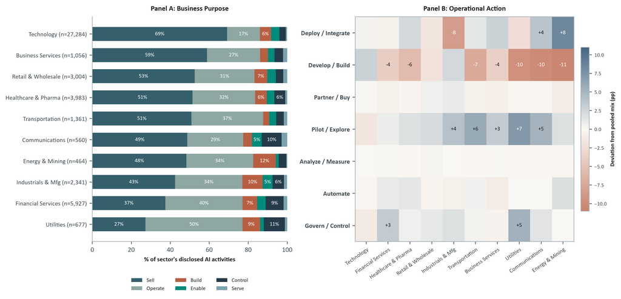

## Archetypes differ most in activity volume and customer orientation: profile by archetype, pooled 2021–2026 YTD

S5 / Thesis Figure 11

↩︎ Supplementary index

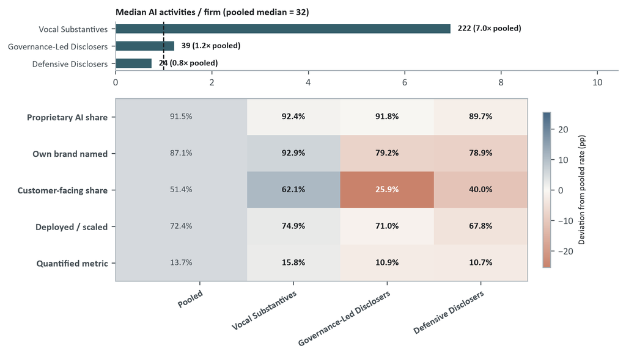

Top panel: median disclosed AI activities per firm relative to the full universe. Bottom panel: raw rates by archetype, with shading indicating percentage-point deviation from the pooled benchmark.

## Mix of disclosed corporate AI activities by disclosure archetype, pooled 2021–2026 YTD

S6 / Thesis Figure 12

↩︎ Supplementary index

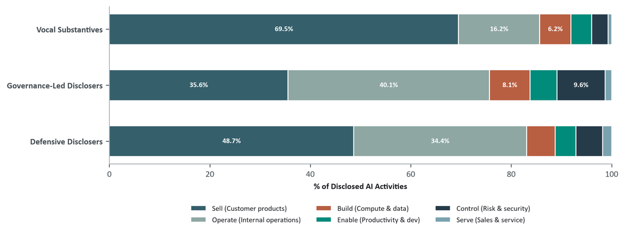

100% stacked horizontal bars: share of each archetype’s disclosed AI activities across six business roles (Sell, Operate, Build, Enable, Control, Serve).

## Decomposing AI activity grounding across all disclosed AI activities, pooled 2021–2026 YTD

S7 / Thesis Figure 13

↩︎ Supplementary index

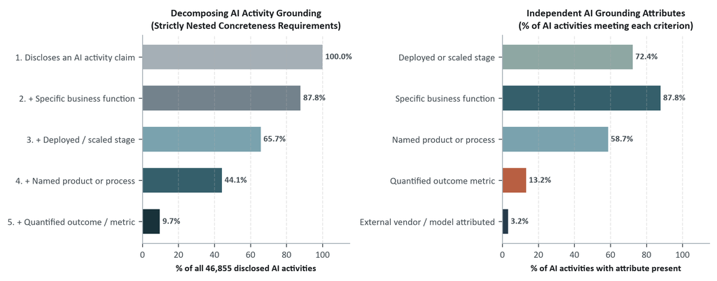

Left: cumulative nested progression of evidence requirements. Right: independent grounding attribute frequencies.

## Corporate branding versus external-vendor attribution in disclosed AI activities, pooled 2021–2026 YTD

S8 / Thesis Figure 15

↩︎ Supplementary index

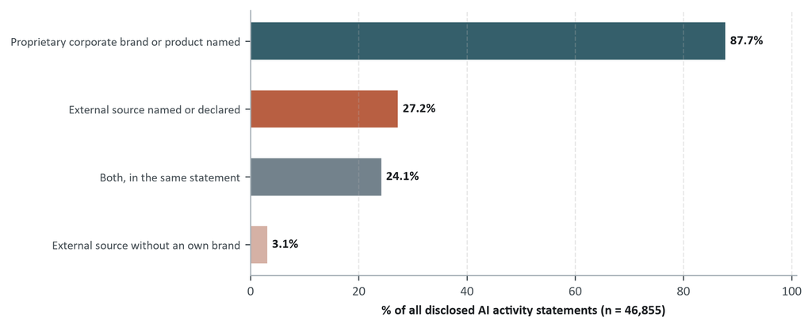

Indicator shares overlap across statements and do not sum to 100. External sources combine named vendors/foundation models, commercial partners, or declared third-party origin, identified via entity tagging and vendor lexicon matching.

## Named technology ecosystems in AI disclosure across S&P 500 firms, 2021–2026 YTD

S9 / Thesis Figure 16

↩︎ Supplementary index

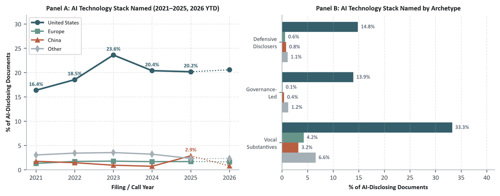

Panel A tracks the share of AI-disclosing documents naming each ecosystem’s stack, with 2026 as a dotted, year-to-date segment; Panel B breaks the same rate down by archetype. The denominator is the 8,452 documents with an AI frame; rates are independent presence indicators, so the four series do not sum to 100.

## Provider families most cited in AI disclosure, by ecosystem and stack role, pooled 2021–2026 YTD

S10 / Thesis Figure 17

↩︎ Supplementary index

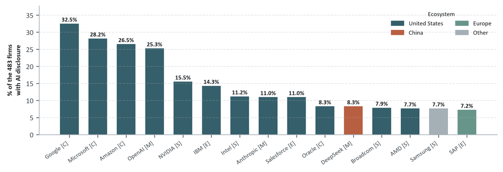

Bars: share of AI-disclosing firms naming each family, colored by ecosystem, with its stack role beside the name (M model, C cloud, S semiconductor, E enterprise software). The 15 most-named of 49 families in the corpus (full list, Thesis Appendix B.6); a firm’s own products are excluded. Only disclosures containing sections identified as AI-related are included.

## Welltower’s annual-report AI disclosure around the SEC comment letter of 2025-04-28, against the mean of three matched real-estate peers

S11 / Thesis Figure 18

↩︎ Supplementary index

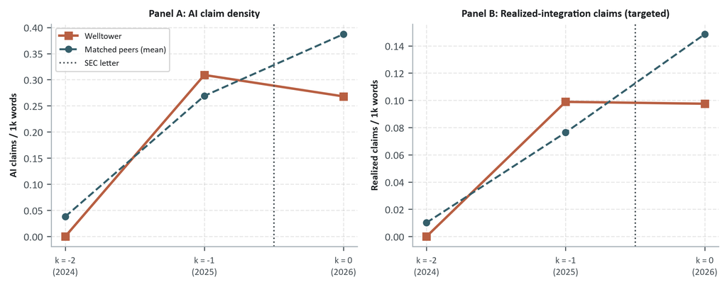

k = −1 is the FY2024 10-K the letter reviewed; k = 0 is the first 10-K filed after the letter. Panel A: AI claim density; Panel B: realized-integration claims, the dimension the staff asked about.

## Disclosure intensity and disclosed substance for selected firms, with the gap between them, end of 2025

S12 / Thesis Figure 21

↩︎ Supplementary index

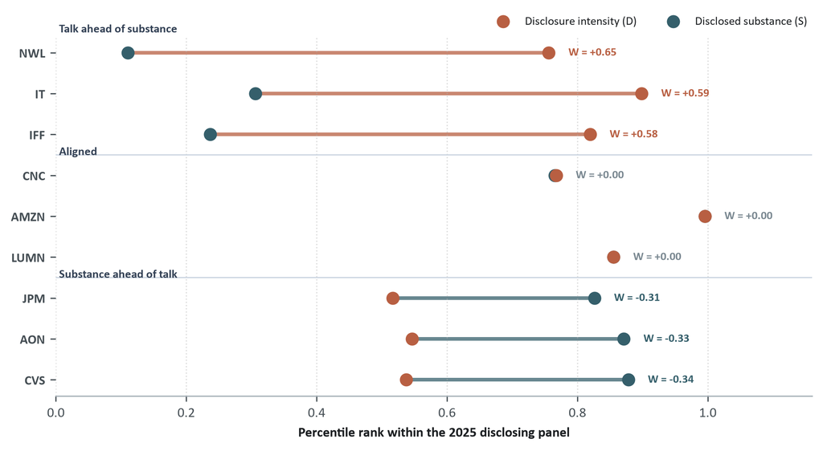

Each line joins a firm’s percentile ranks of disclosure intensity (D) and disclosed substance (S); the gap between the two endpoints is W. Cases show the three largest positive, negative, and near-zero gaps among firms in the upper half of D in 2025.

## Call-minus-filing gap by fiscal year on three evidentiary dimensions, 2021–2026 YTD

S13 / Thesis Figure 23

↩︎ Supplementary index

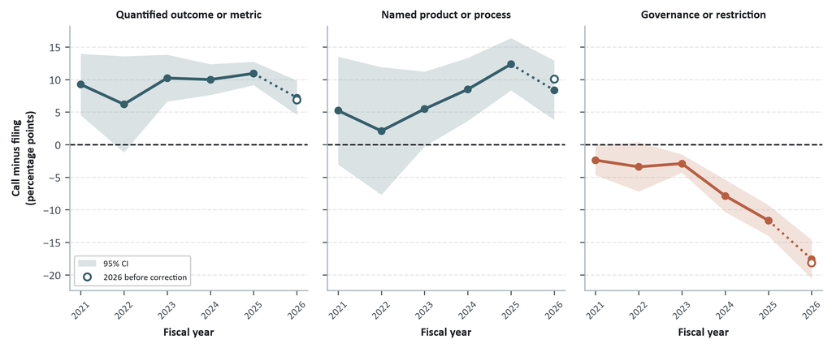

Each point: mean call-minus-filing gap across that year’s firm × fiscal-year cells, with the 95% CI from a one-sample t-test. 2026 is still open at the 2026-09-03 cut-off and is seasonally corrected (Thesis Appendix A.3); the hollow marker is the uncorrected value. Cells per year: 2021: 57, 2022: 56, 2023: 103, 2024: 152, 2025: 228, 2026: 194.

## Calls amplify both promotion and quantified evidence: call-to-filing amplification ratios per 1,000 words, pooled 2021–2026 YTD

S14 / Thesis Figure 24

↩︎ Supplementary index

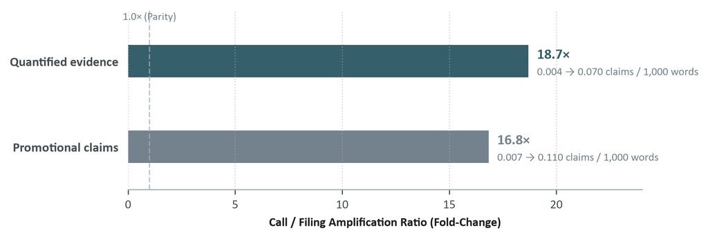

Relative amplification in quantified evidence exceeds that of promotional claims.

## At equal disclosure volume, Vocal and Governance-Led firms report more activities; Vocal is most customer-facing

S15 / Activities vs. Defensive

↩︎ Supplementary index

Disclosed AI activities vs. Defensive, at equal disclosure volume

[figure not shown]

Customer-facing share of activities

[figure not shown]

Pooled 2021–2026 year to date, 451 active index firms · Thesis Table 40  
Left: negative binomial of activity counts on posture, controlling for log(1 + AI frames), 95% CI; Defensive = 1. Right: share of each posture’s activities aimed at customers; dashed line = pooled share.

## All 48 market tests: few clear the multiple-testing threshold

S16 / Market tests

↩︎ Supplementary index

[figure not shown]

9,350 earnings calls by 484 firms, 2021–2026 · Thesis Table 46  
Benjamini–Hochberg false-discovery control over the whole family of 8 outcomes × 6 disclosure variables, not outcome by outcome.

## The thesis checklist: the same six questions for an issuer writing and an investor reading

S17 / Credibility checklist

↩︎ Supplementary index

|  | Issuer | Investor |
| --- | --- | --- |
| **0. Posture** | Know which posture your writing resembles; calibrate the rest to it. | Posture says how a firm writes, not whether it is backed. |
| **1. Activity & maturity** | Separate pilots from deployed systems; name the function. | Discount vague “exploring”; check it reached production. |
| **2. Evidence** | Name products and tools; give metrics (cost, speed, revenue). | Look for metrics you could check; buzzwords need more checking. |
| **3. Provenance** | Say if it is built in-house, licensed, or co-developed. | Check vendor dependence; unstated origin sits in the weakest claims. |
| **4. Calls vs. 10-K** | Reconcile call remarks with the signed 10-K. | Question claims with less evidence in the 10-K than on the call. |
| **5. Oversight** | Board and audit oversight of AI risk in the proxy; named owners. | Are owners, controls and scope clearly identified? |

Shortened from Thesis Table 20, the AI Disclosure Credibility Checklist (issuer guidance and investor read). Each line pairs a question with the action it implies.